# ConsensusMetaDA: an R Package for consensus-based differential abundance analysis of metagenomic data.

Manoharan Kumar, Matt Field

Last modified: 2026-09-01. Compiled: 2026-09-09

# 1 Introduction to ConsensusMetaDA

ConsensusMetaDA is an R package for microbiome differential abundance (DA) analysis using multiple algorithms and reaching a consensus. No single tool performs best on all metagenomic datasets, so a consensus approach yields more robust differentially abundant taxa. ConsensusMetaDA runs **seven** widely used tools — edgeR, DESeq2, ALDEx2, metagenomeSeq, ADAPT, ANCOM-BC2, and MaAsLin3 — takes standard biom + sample table input, and also produces microbiome visualisations (alpha diversity, beta diversity, rarefaction, bidirectional and scaled plots).

Consensus is reached three ways: vote rules (union / k-of-7 / intersect), p-value combination (Fisher, Stouffer, and the dependence-robust Cauchy/ACAT), and rank-sum aggregation.

ConsensusMetaDA is organised around two core functions:

- `build_OTU_counts()` — build (or filter) a phyloseq object from a biom file + sample table (+ optional taxonomy), or from an existing phyloseq object.
- `OTUs_multi_DA()` — perform DA analysis across all pairwise comparisons.

Plotting is provided by `OTUs_plots()`.

```r
# ADAPT requires R >= 4.4 (use R 4.4.2)
# if (!require("BiocManager", quietly = TRUE)) install.packages("BiocManager")
# for (pkg in c("phyloseq","DESeq2","ALDEx2","edgeR","metagenomeSeq","ANCOMBC"))
#   if (!require(pkg, character.only = TRUE)) BiocManager::install(pkg)
# # ADAPT, maaslin3 as per their install instructions
# if (!require("ConsensusMetaDA", quietly = TRUE)) {
#   if (!require("remotes", quietly = TRUE)) install.packages("remotes")
#   remotes::install_github("kmanoharan01/ConsensusMetaDA")
# }
```

## 1.1 Load libraries

```r
library(ggplot2)
library(phyloseq)
library(vegan)
library(ConsensusMetaDA)
```

# 2 Example data

We use the bundled `ecc_saliva` dataset (early-childhood-caries saliva microbiome). It is available both as example files under `inst/extdata/` and as a ready-made phyloseq object via `data()`.

```r
library(ADAPT)
data("ecc_saliva")
ecc_saliva
```

```
## phyloseq-class experiment-level object
## otu_table()   OTU Table:         [ 280 taxa and 161 samples ]
## sample_data() Sample Data:       [ 161 samples by 2 sample variables ]
## tax_table()   Taxonomy Table:    [ 280 taxa by 7 taxonomic ranks ]
## refseq()      DNAStringSet:      [ 280 reference sequences ]
```

```r
# resolve bundled example files (works regardless of working directory)
ecc_saliva_biom         <- system.file("extdata", "ecc_saliva_Otu.biom",
                                        package = "ConsensusMetaDA")
ecc_saliva_sample_table <- system.file("extdata", "ecc_saliva_sample_table.txt",
                                        package = "ConsensusMetaDA")

# taxonomy taken from the bundled object so it matches the biom's ASV ids
ecc_saliva_tax <- tax_table(ecc_saliva)
```

# 3 Building a phyloseq object

`build_OTU_counts()` has two entry points and optional filters (`abundance_threshold`, `prevalence_threshold`, `rarity_threshold`, `variance_threshold`). **Because the first argument is now `physeq`, always call it with named arguments.**

## 3.1 From files (biom + sample table + taxonomy)

```r
ecc_saliva_build_OTU_counts <- build_OTU_counts(
  biom                 = ecc_saliva_biom,
  sample_table         = ecc_saliva_sample_table,
  tax_tables           = ecc_saliva_tax,
  abundance_threshold  = 10,
  prevalence_threshold = 0.1,
  rarity_threshold     = 0,
  variance_threshold   = 0
)
ecc_saliva_build_OTU_counts
```

```
## phyloseq-class experiment-level object
## otu_table()   OTU Table:         [ 114 taxa and 161 samples ]
## sample_data() Sample Data:       [ 161 samples by 3 sample variables ]
## tax_table()   Taxonomy Table:    [ 114 taxa by 7 taxonomic ranks ]
```

## 3.2 From a prebuilt phyloseq object

When you already have a phyloseq object, pass it via `physeq =` and use the function purely for filtering. This is orientation-safe (it transposes internally when taxa are stored as columns).

```r
ecc_ps <- build_OTU_counts(physeq = ecc_saliva, prevalence_threshold = 0.1)
ecc_ps
```

```
## phyloseq-class experiment-level object
## otu_table()   OTU Table:         [ 114 taxa and 161 samples ]
## sample_data() Sample Data:       [ 161 samples by 2 sample variables ]
## tax_table()   Taxonomy Table:    [ 114 taxa by 7 taxonomic ranks ]
## refseq()      DNAStringSet:      [ 114 reference sequences ]
```

## 3.3 Individual filters

Each filter can be used on its own.

```r
build_OTU_counts(biom = ecc_saliva_biom, sample_table = ecc_saliva_sample_table,
                 tax_tables = ecc_saliva_tax, rarity_threshold = 0.1)
```

```
## phyloseq-class experiment-level object
## otu_table()   OTU Table:         [ 244 taxa and 161 samples ]
## sample_data() Sample Data:       [ 161 samples by 3 sample variables ]
## tax_table()   Taxonomy Table:    [ 244 taxa by 7 taxonomic ranks ]
```

```r
build_OTU_counts(biom = ecc_saliva_biom, sample_table = ecc_saliva_sample_table,
                 tax_tables = ecc_saliva_tax, abundance_threshold = 10)
```

```
## phyloseq-class experiment-level object
## otu_table()   OTU Table:         [ 238 taxa and 161 samples ]
## sample_data() Sample Data:       [ 161 samples by 3 sample variables ]
## tax_table()   Taxonomy Table:    [ 238 taxa by 7 taxonomic ranks ]
```

```r
build_OTU_counts(biom = ecc_saliva_biom, sample_table = ecc_saliva_sample_table,
                 tax_tables = ecc_saliva_tax, prevalence_threshold = 0.1)
```

```
## phyloseq-class experiment-level object
## otu_table()   OTU Table:         [ 114 taxa and 161 samples ]
## sample_data() Sample Data:       [ 161 samples by 3 sample variables ]
## tax_table()   Taxonomy Table:    [ 114 taxa by 7 taxonomic ranks ]
```

```r
build_OTU_counts(biom = ecc_saliva_biom, sample_table = ecc_saliva_sample_table,
                 tax_tables = ecc_saliva_tax, variance_threshold = 0.2)
```

```
## phyloseq-class experiment-level object
## otu_table()   OTU Table:         [ 241 taxa and 161 samples ]
## sample_data() Sample Data:       [ 161 samples by 3 sample variables ]
## tax_table()   Taxonomy Table:    [ 241 taxa by 7 taxonomic ranks ]
```

# 4 Performing differential abundance

`OTUs_multi_DA()` runs the seven tools on every pairwise comparison of the grouping variable (default `group_var = "Group"`) and consolidates the results. An UpSet plot is written per comparison.

```r
ecc_saliva_DA <- OTUs_multi_DA(ecc_saliva_build_OTU_counts,
                               group_var = "Group", fdr_cut = 0.05)
```

```
## Choose 'Control' as the baseline condition
## 114 taxa and 161 samples being analyzed...
## Selecting Reference Set... 28 taxa selected as reference
## 25 differentially abundant taxa detected
## Differential abundance analysis for Group (Case VS Control)
## 114 taxa and 161 samples analyzed
## 28 taxa are selected as reference and 25 taxa are differentially abundant
```

```
##
## --------------------------------------------------
##   Consensus summary - Case_vs_Control  (FDR < 0.05)
## --------------------------------------------------
##   Tools that ran      : 7
##   Total taxa tested   : 114
##
##   Taxa significant by N tools:
##     1/7 tools : 37
##     2/7 tools : 16
##     3/7 tools : 4
##     4/7 tools : 3
##     5/7 tools : 4
##     6/7 tools : 2
##     7/7 tools : 1
##
##   Consensus tiers (vote rules):
##     Any tool (>=1)          : 67
##     Majority (>=4)          : 10
##     Strict (>=6, all-but-1) : 3
##     Unanimous (7/7)        : 1
##
##   Combined-p methods:
##     Fisher                    : 58
##     Stouffer                  : 56
##     Cauchy (dependence-robust): 50
## --------------------------------------------------
```

```r
names(ecc_saliva_DA)                     # the contrasts that were run
```

```
## [1] "Case_vs_Control"
```

```r
cons <- ecc_saliva_DA[[1]]$consolidated  # consolidated table for first contrast
```

## 4.1 The consolidated table

For each taxon the consolidated table carries, per tool, a log fold-change, p-value, adjusted p-value and significance flag, plus:

- `n_sig` — how many of the seven tools called the taxon significant
- `n_tools` — how many tools ran
- **combined p-values** (appended automatically):
  - `p_fisher`, `padj_fisher`, `sig_fisher`
  - `p_stouffer`, `padj_stouffer`, `sig_stouffer`
  - `p_cauchy`, `padj_cauchy`, `sig_cauchy`

Because the seven tools share the same count matrix and overlapping models (i.e. their p-values are correlated), the **Cauchy (ACAT)** combiner is recommended — it is valid under arbitrary dependence. Fisher and Stouffer assume independence and are provided as comparators.

```r
grep("fisher|stouffer|cauchy", names(cons), value = TRUE)
```

```
## [1] "p_fisher"      "padj_fisher"   "sig_fisher"    "p_stouffer"    "padj_stouffer" "sig_stouffer"  "p_cauchy"      "padj_cauchy"   "sig_cauchy"
```

There is deliberately **no composite fold-change column**: the tools report fold-change on different footings (ALDEx2’s `effect` is a standardized effect size, not a log2 fold-change; ANCOM-BC2 / MaAsLin3 / metaSeq each carry their own normalization), so averaging them would mix different quantities. Read each tool’s `logFC_<tool>` column directly if needed.

## 4.2 Consensus decision rules

`compare_decision_rules()` puts every strategy side by side — vote rules, the three combiners, and rank-sum aggregation.

```r
compare_decision_rules(cons, fdr_cut = 0.05)
```

```
##                                   rule      method votes n_called
## 1                       Union (1 of 7)        vote     1       67
## 2                               2 of 7        vote     2       30
## 3                               3 of 7        vote     3       14
## 4                               4 of 7        vote     4       10
## 5                               5 of 7        vote     5        7
## 6                               6 of 7        vote     6        3
## 7                   Intersect (7 of 7)        vote     7        1
## 8                      Fisher combined combination    NA       58
## 9                    Stouffer combined combination    NA       56
## 10 Cauchy combined (dependence-robust) combination    NA       50
## 11                Rank-sum aggregation combination    NA       14
```

## 4.3 Compact summary table

`build_summary_table()` gives per-tool adjusted p-values and ranks, the rank-sum, and the order-statistic p-values `p_union` / `p_atleast2` / `p_intersect_all`. Threshold `p_union` for the union, `p_intersect_all` for the intersect, and use `p_atleast_k()` for any *k*.

```r
st <- build_summary_table(cons)
st$p_atleast5 <- p_atleast_k(st, k = 5)   # "at least 5 of 7 tools" p-value
head(st)
```

```
##     Taxa  edgeR_adj_p DESeq2_adj_p ALDEx2_adj_p metaSeq_adj_p  ADAPT_adj_p ANCOMBC2_adj_p MaAsLin3_adj_p edgeR_rank DESeq2_rank ALDEx2_rank metaSeq_rank ADAPT_rank ANCOMBC2_rank MaAsLin3_rank
## 15 ASV18 4.281931e-04  0.082920511 2.795217e-04  0.0012935611 5.548603e-06   5.376154e-04    0.013488835       15.0         3.0           2            2        2.0            11           4.0
## 6   ASV8 4.593266e-07  0.001290811 9.164436e-03  0.0001344934 7.477042e-03   1.764271e-03    0.004500716        6.0         1.0           6            1       14.5            13           1.5
## 9  ASV47 7.411089e-07  0.092938627 7.801526e-02  0.0046595104 2.874239e-02   1.927249e-04    0.165066942        9.0         4.0          13            5       21.0             8          11.0
## 11 ASV30 3.384384e-06  0.126929241 4.089327e-02  0.0046595104 2.069622e-02   2.120209e-03    0.117423601       10.5         7.5           9            5       18.0            16           9.0
## 1  ASV71 1.037937e-15  0.126929241 1.337515e-01  0.0436115135 4.001121e-02   1.202799e-06    0.359252789        1.0         7.5          19           10       23.0             1          19.5
## 3  ASV20 4.493931e-10  0.034047043 5.365793e-05  0.0032328955 1.454310e-06   2.642663e-02    0.526957298        3.0         2.0           1            3        1.0            30          41.5
##    rank_sum      p_union   p_atleast2 p_intersect_all  p_atleast5
## 15     39.0 5.548603e-06 2.795217e-04     0.082920511 0.001293561
## 6      43.0 4.593266e-07 1.344934e-04     0.009164436 0.004500716
## 9      71.0 7.411089e-07 1.927249e-04     0.165066942 0.078015263
## 11     75.0 3.384384e-06 2.120209e-03     0.126929241 0.040893270
## 1      81.0 1.037937e-15 1.202799e-06     0.359252789 0.126929241
## 3      81.5 4.493931e-10 1.454310e-06     0.526957298 0.026426626
```

```r
describe_summary_table()                  # column dictionary
```

```
##            column                               description                                                                      detail
## 1    <tool>_adj_p                          Per-tool p-value                                          BH-adjusted p-value from that tool
## 2     <tool>_rank Rank of the p-value reported by that tool                      Smallest rank = most significant reported by that tool
## 3        rank_sum                              Sum of ranks                    Sum of every <tool>_rank column. Table is sorted by this
## 4         p_union        Smallest adjusted p-value observed          Threshold for the UNION: p_union < cutoff means >=1 tool called it
## 5      p_atleast2    2nd-smallest adjusted p-value observed Threshold for AT LEAST 2 tools. Use p_atleast_k(summary_tab, k) for other k
## 6 p_intersect_all         Largest adjusted p-value observed                           Threshold for the INTERSECT: every tool called it
```

The summary-table columns are:

- `<tool>_adj_p` — BH-adjusted p-value from each tool
- `<tool>_rank` — rank of that tool’s p-value (smallest = most significant)
- `rank_sum` — sum of the per-tool ranks (table is sorted by this)
- `p_union` — smallest adjusted p-value across tools (threshold → union)
- `p_atleast2` — 2nd-smallest (threshold → “≥2 tools”); `p_atleast_k()` for other k
- `p_intersect_all` — largest adjusted p-value (threshold → intersect)

# 5 Plotting functions

`OTUs_plots()` creates five plots — (1) alpha diversity (Shannon), (2) beta diversity (PCoA), (3) rarefaction curve, (4) scaled taxa-level plot and (5) bidirectional plots — and saves them as PDFs. It also returns them as objects for inline display. See `?OTUs_plots`.

```r
ecc_saliva_plots <- OTUs_plots(ecc_saliva_build_OTU_counts)
```

```
## Running comparison: Control_vs_Case
## Processing: Phylum for Control vs Case
```

```
## Completed: Phylum for Control vs Case
## Processing: Class for Control vs Case
```

```
## Completed: Class for Control vs Case
## Processing: Order for Control vs Case
```

```
## Completed: Order for Control vs Case
## Processing: Family for Control vs Case
```

```
## Completed: Family for Control vs Case
## Processing: Genus for Control vs Case
```

```
## Completed: Genus for Control vs Case
## Running comparison: Case_vs_Control
## Processing: Phylum for Case vs Control
```

```
## Completed: Phylum for Case vs Control
## Processing: Class for Case vs Control
```

```
## Completed: Class for Case vs Control
## Processing: Order for Case vs Control
```

```
## Completed: Order for Case vs Control
## Processing: Family for Case vs Control
```

```
## Completed: Family for Case vs Control
## Processing: Genus for Case vs Control
```

```
## Completed: Genus for Case vs Control
```

## 5.2 Alpha diversity

Alpha diversity (Shannon index) measures within-sample richness and evenness.

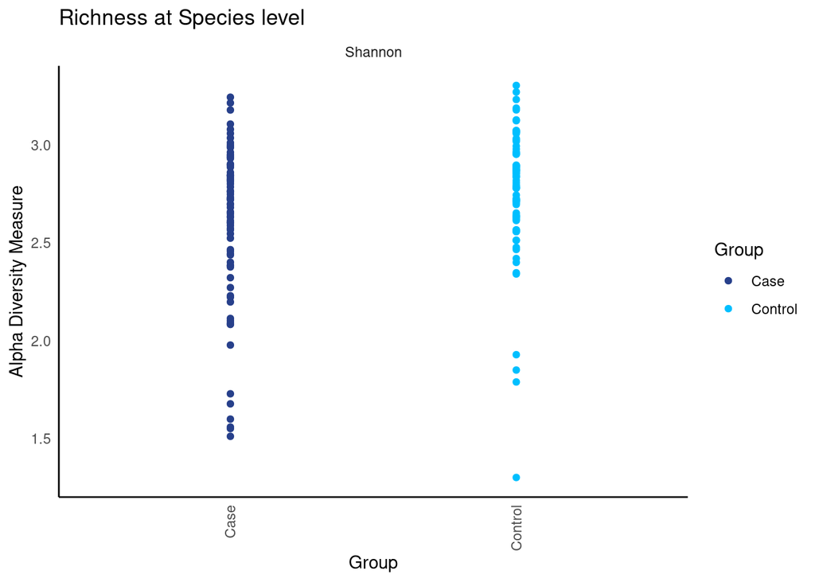

```r
print(ecc_saliva_plots$AlphaDiv$tax_level)
```

## 5.3 Beta diversity / PCoA

Beta diversity (principal coordinates analysis) shows how microbiome composition differs among groups and samples.

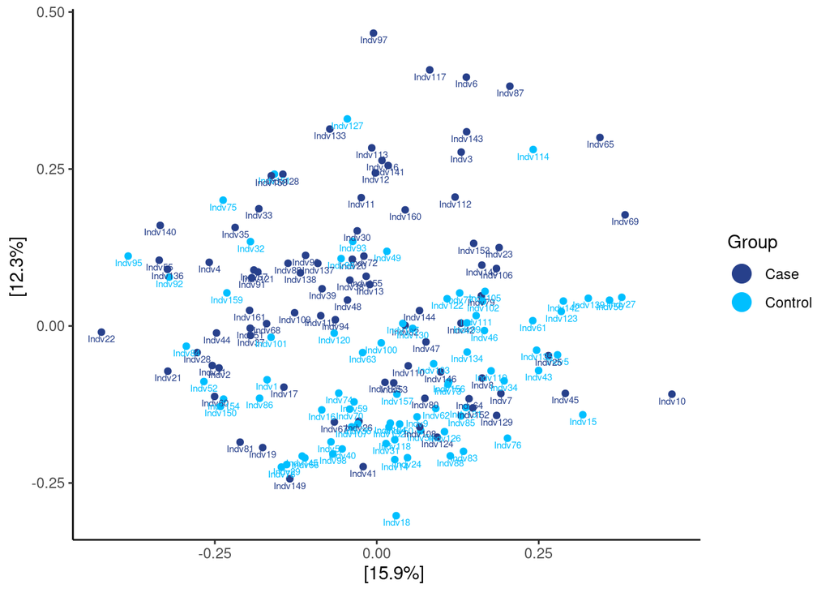

```r
print(ecc_saliva_plots$BetaDiv)
```

## 5.4 Bidirectional plot

A bidirectional plot shows two groups’ mean abundance and prevalence together, richer than either alone.

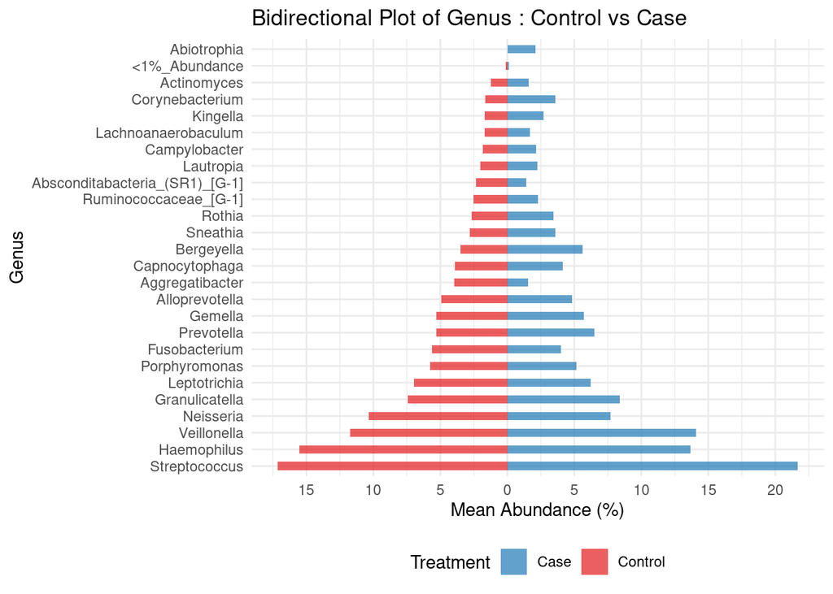

```r
print(ecc_saliva_plots$all_comparisons_results$Control_vs_Case$Genus_plot)
```

Interpretation:

- High abundance + high prevalence — beneficial bacteria expanding
- Higher abundance + lower prevalence — pathogen blooming in some individuals
- Lower abundance + higher prevalence — opportunists colonising stressed communities
- Lower abundance + lower prevalence — sensitive bacteria dying off

# 6 Citing ConsensusMetaDA

When using this package, please cite ConsensusMetaDA and every method used.

```r
citation("ConsensusMetaDA")
```

**DA tools**

- **DESeq2** — Love, M.I., Huber, W., Anders, S. (2014). Moderated estimation of fold change and dispersion for RNA-seq data with DESeq2. *Genome Biology* 15(12):550.
- **edgeR** — Robinson MD, McCarthy DJ, Smyth GK (2010). *Bioinformatics* 26, 139–140. McCarthy DJ, Chen Y, Smyth GK (2012). *Nucleic Acids Research* 40, 4288–4297.
- **ALDEx2** — Fernandes, A.D. et al. (2013). ANOVA-Like Differential Expression (ALDEx) Analysis for Mixed Population RNA-Seq. *PLOS ONE* 8(7), e67019.
- **ADAPT** — Wang, M., Fontaine, S., Jiang, H., Li, G. (2024). ADAPT: Analysis of Microbiome Differential Abundance by Pooling Tobit Models. *Bioinformatics* 40(11).
- **metagenomeSeq** — Paulson JN, Stine OC, Bravo HC, Pop M (2013). Differential abundance analysis for microbial marker-gene surveys. *Nature Methods* 10, 1200–1202.
- **ANCOM-BC2** — Lin, H., Peddada, S.D. (2020). Analysis of compositions of microbiomes with bias correction. *Nature Communications* 11, 3514.
- **MaAsLin** — Mallick, H. et al. (2021). Multivariable association discovery in population-scale meta-omics studies. *PLoS Computational Biology* 17(11), e1009442.

**Consensus / combination methods**

- **Cauchy combination (recommended)** — Liu, Y., Xie, J. (2020). Cauchy combination test: a powerful test with analytic p-value calculation under arbitrary dependency structures. *JASA* 115(529), 393–402.
- **ACAT** — Liu, Y. et al. (2019). ACAT: a fast and powerful p-value combination method for rare-variant analysis. *AJHG* 104(3), 410–421.
- **Fisher’s method** — Fisher, R.A. (1932). *Statistical Methods for Research Workers*, 4th ed. Oliver and Boyd.
- **Stouffer’s Z** — Stouffer, S.A. et al. (1949). *The American Soldier, Vol. 1*. Princeton University Press.
- **Rank aggregation** — Guo, Zhao, Ye, Sheng, Shyr (2014).

**Framework**